# VLM Wrong Predictions: attr_structure_position [both_right]

Actual: At-Grade

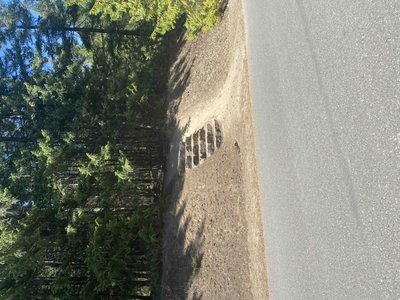

12889__AST_EX_20210811_143907.jpeg

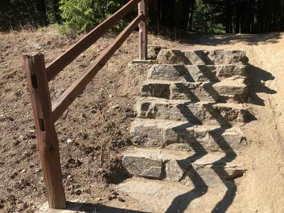

88160__AST_EX_20250917_140440.jpeg

Asset 53807 2 images

Predicted: VLM: At-Grade | DINOv3: At-Grade (conf: N/A)

Actual: At-Grade

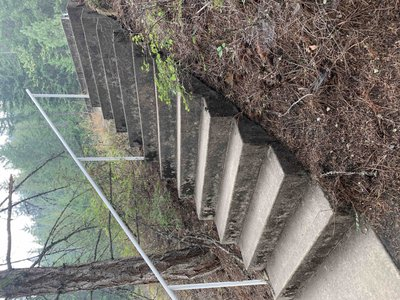

11709__AST_EX_20210806_115724.jpeg

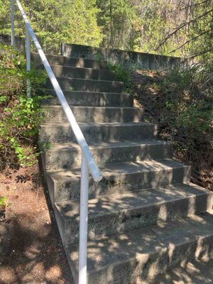

86142__AST_EX_20250811_120903.jpeg

Asset 53808 2 images

Predicted: VLM: At-Grade | DINOv3: At-Grade (conf: N/A)

Actual: At-Grade

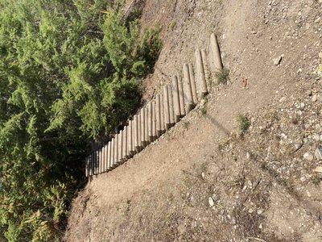

13956__AST_EX_20210812_111719.jpeg

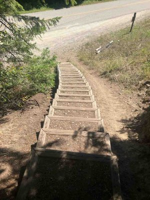

86160__AST_EX_20250811_140653.jpeg

Asset 54159 3 images

Predicted: VLM: At-Grade | DINOv3: At-Grade (conf: N/A)

Actual: At-Grade

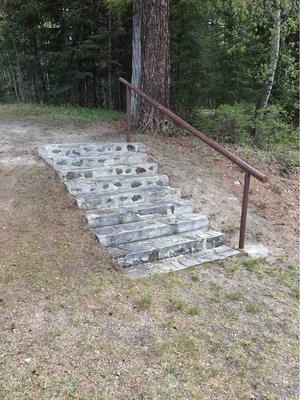

43359__AST_EX_20220528_151418.jpeg

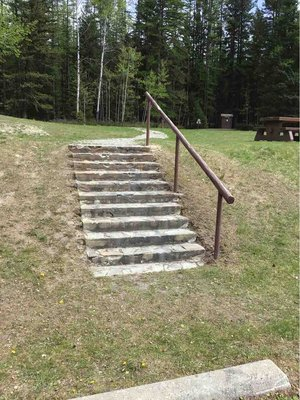

43361__AST_EX_20220528_151355.jpeg

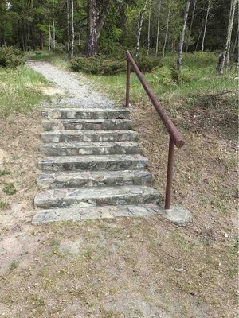

43376__AST_EX_20220528_151346.jpeg

Asset 54337 1 image

Predicted: VLM: At-Grade | DINOv3: At-Grade (conf: N/A)

Actual: At-Grade

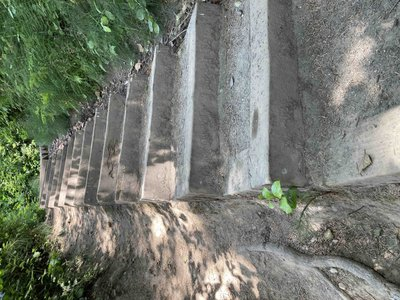

7553__AST_EX_20210723_133711.jpeg

Asset 54506 1 image

Predicted: VLM: At-Grade | DINOv3: At-Grade (conf: N/A)

Actual: At-Grade

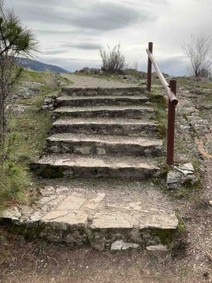

37591__AST_EX_20220325_143205.jpeg

Asset 55707 2 images

Predicted: VLM: Elevated | DINOv3: Elevated (conf: N/A)

Actual: Elevated

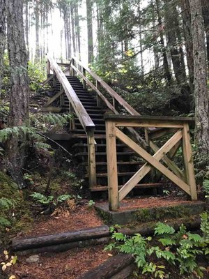

26916__AST_EX_20211014_124832.jpeg

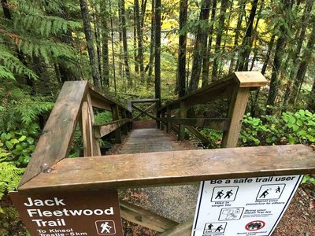

26920__AST_EX_20211014_124750.jpeg

Asset 55708 1 image

Predicted: VLM: At-Grade | DINOv3: At-Grade (conf: N/A)

Actual: At-Grade

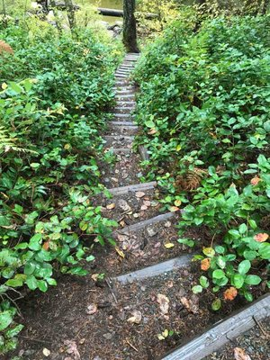

26930__AST_EX_20211014_123431.jpeg

Asset 55912 2 images

Predicted: VLM: At-Grade | DINOv3: At-Grade (conf: N/A)

Actual: At-Grade

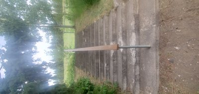

1367__MI_20210618_151214.jpg

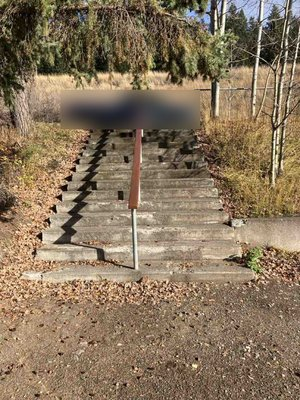

76533__AST_EX_20241029_115528.jpeg

Asset 56479 5 images

Predicted: VLM: At-Grade | DINOv3: At-Grade (conf: N/A)

Actual: At-Grade

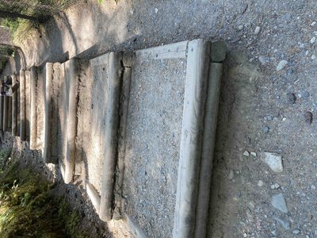

16404__AST_EX_20210819_115352.jpeg

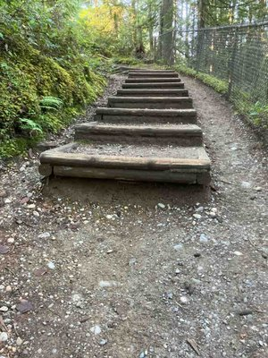

78521__AST_EX_20250121_121720.jpeg

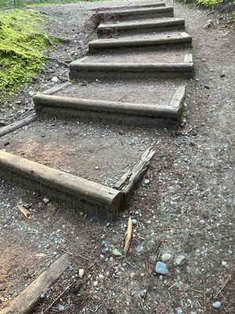

78522__AST_EX_20250121_121653.jpeg

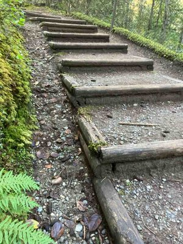

78523__AST_EX_20250121_121713.jpeg

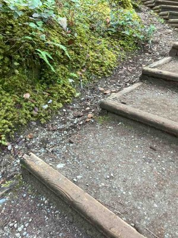

78525__AST_EX_20250121_121706.jpeg

Asset 56563 2 images

Predicted: VLM: At-Grade | DINOv3: At-Grade (conf: N/A)

Actual: At-Grade

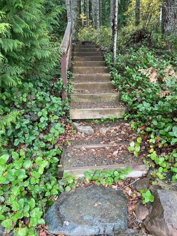

77183__AST_EX_20241107_121654.jpeg

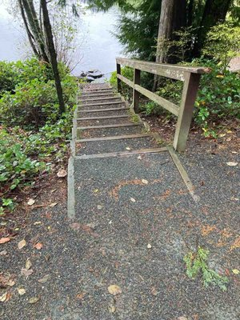

77184__AST_EX_20241107_121636.jpeg

Asset 56878 2 images

Predicted: VLM: At-Grade | DINOv3: At-Grade (conf: N/A)

Actual: At-Grade

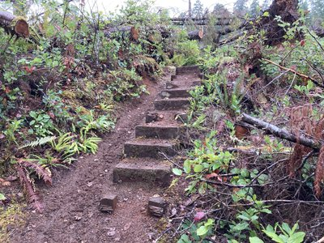

21688__IMG_0698.JPG

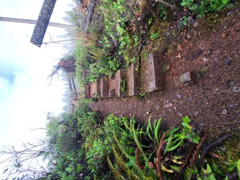

76059__s14stairs2.jpg

Asset 57614 2 images

Predicted: VLM: Elevated | DINOv3: Elevated (conf: N/A)

Actual: Elevated

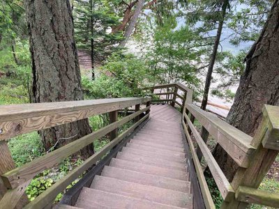

47880__AST_EX_20220621_115244.jpeg

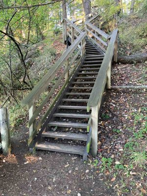

73034__AST_EX_20240831_100128.jpeg

Asset 57673 1 image

Predicted: VLM: At-Grade | DINOv3: At-Grade (conf: N/A)

Actual: At-Grade

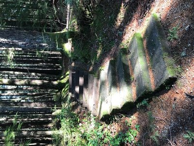

32620__4_Stairs_at_site_10.jpg

Asset 57674 1 image

Predicted: VLM: At-Grade | DINOv3: At-Grade (conf: N/A)

Actual: At-Grade

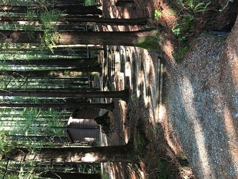

32616__2_Stairs_to_Outhouse.jpg

Asset 58180 1 image

Predicted: VLM: At-Grade | DINOv3: At-Grade (conf: N/A)

Actual: At-Grade

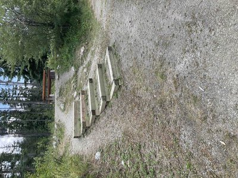

8069__AST_EX_20210726_120559.jpeg

Asset 60066 1 image

Predicted: VLM: At-Grade | DINOv3: At-Grade (conf: N/A)

Actual: At-Grade

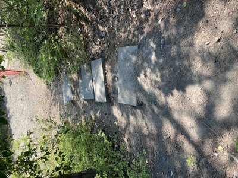

7165__AST_EX_20210721_105155.jpeg

Asset 60443 2 images

Predicted: VLM: At-Grade | DINOv3: At-Grade (conf: N/A)

Actual: At-Grade

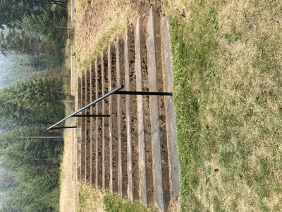

8980__AST_EX_20210729_101858.jpeg

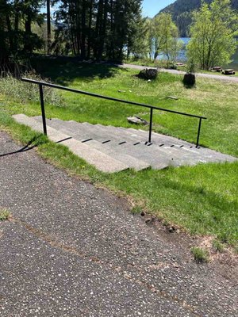

81678__AST_EX_20250505_105146.jpeg

Asset 60444 2 images

Predicted: VLM: At-Grade | DINOv3: At-Grade (conf: N/A)

Actual: At-Grade

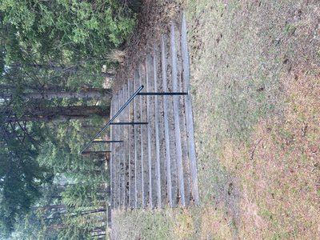

9013__AST_EX_20210729_093207.jpeg

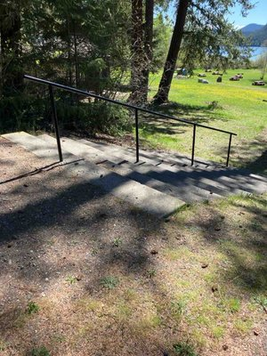

81666__AST_EX_20250505_105446.jpeg

Asset 61221 1 image

Predicted: VLM: At-Grade | DINOv3: At-Grade (conf: N/A)

Actual: At-Grade

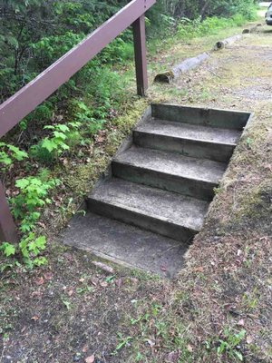

45850__AST_EX_20220610_140536.jpeg

Asset 61611 1 image

Predicted: VLM: At-Grade | DINOv3: At-Grade (conf: N/A)

Actual: At-Grade

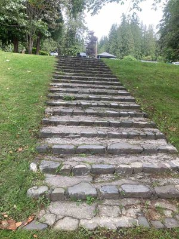

53100__AST_EX_20220710_120328.jpeg

Asset 61933 1 image

Predicted: VLM: Elevated | DINOv3: Elevated (conf: N/A)

Actual: Elevated

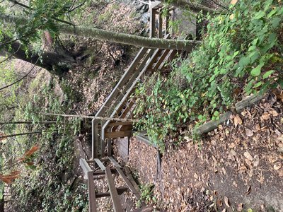

72806__IMG_0116_1_.JPG

Asset 62338 2 images

Predicted: VLM: At-Grade | DINOv3: At-Grade (conf: N/A)

Actual: At-Grade

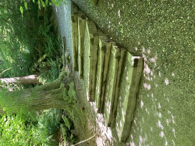

2493__AST_EX_20210625_105957.jpeg

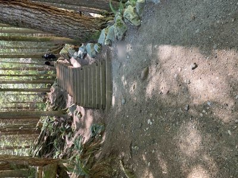

2627__AST_EX_20210625_111415.jpeg

Asset 63006 3 images

Predicted: VLM: Elevated | DINOv3: Elevated (conf: N/A)

Actual: Elevated

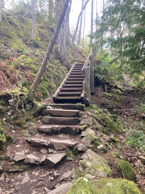

64743__AST_EX_20230310_133045.jpeg

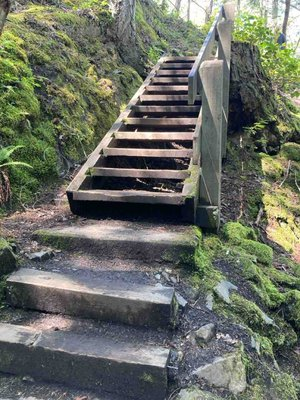

82180__AST_EX_20250518_134142.jpeg

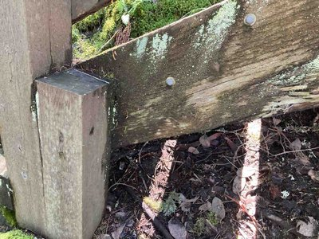

82181__AST_EX_20250518_134123.jpeg

Asset 63400 1 image

Predicted: VLM: At-Grade | DINOv3: At-Grade (conf: N/A)

Actual: At-Grade

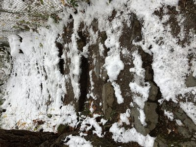

64156__IMG_0455.jpg